# Central Limit Therom - creating sample distributions.

In this demonstration, I want to get a practical feel for the central limit theorem by generating sample distributions. I want to see how n affects the distribution and how the n inversely affects the sample standard deviation. The point of this demonstration is for me to put my knowledge into practice and visually demonstrate to my self the central limit theorem.

```python
import numpy as np
import math as math
import random
import matplotlib.pyplot as plt
import pandas as pd
import seaborn as sns
```

```python
#Gen 100 ints between 0 and 6, creating a sample size of 100.
def Generate():
    sample = []
    for i in range(100):
        a = random.randint(0,6)
        sample.append(a)
    return (sample)

#run the generator
s = Generate()
sample = pd.Series(s)

#create a prob distribution of the original sample data
sample_prob = sample.value_counts() /100
```

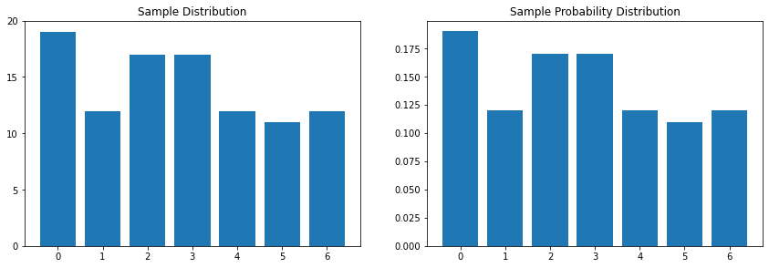

```python
fig = plt.figure(figsize=(14.5,10))
ax1 = fig.add_subplot(2,2,1)
ax2 = fig.add_subplot(2,2,2)
ax1.bar(x=sample.value_counts().index,height =sample.value_counts())
ax2.bar(x=sample_prob.index,height =sample_prob)

ax1.set_title('Sample Distribution')
ax2.set_title('Sample Probability Distribution')

ax1.set_yticks(range(0,21,5))
```

```python
#This class when called with generate a rnd number between 0 and the length of the sample list.
#It will loop this process s_len times to create a sample, this will be appended to n_samples.
#This whole process will look n times to generate a n amount of randomly selected samples from the sample data.

def Fetch_samples(data,n=None,sample_size=None):
    if n == None:
        n=10

    if sample_size == None:
        sample_size =5

    n_samples=[]
    for i in range(0,sample_size):
        s = []
        for i in range(0,n):
            i = random.randint(0,(len(data)-1))
            s.append(data[i])
        n_samples.append(s)

    print(len(n_samples),"Random Samples taken")

    return n_samples
```

```python
#Fetch_samples(data,n=None,s_len=None)
#n: size of each sample
#s_len: number of samples

n_samples = Fetch_samples(sample,n=10,sample_size= 1000)
```

```
1000 Random Samples taken
```

```python
#Convert n_sample list to Pandas DataFrame inorder to use Vectorising when calculating the means.

sample_ready = pd.DataFrame(n_samples)
sample_ready['s_mean'] = round(sample_ready.mean(axis='columns'),2)
distribution_mean = round(sample_ready['s_mean'].mean(axis='rows'),2)
```

```python
sample_ready
```

|  | 0 | 1 | 2 | 3 | 4 | 5 | 6 | 7 | 8 | 9 | s_mean |
| --- | --- | --- | --- | --- | --- | --- | --- | --- | --- | --- | --- |
| 0 | 2 | 6 | 4 | 3 | 0 | 4 | 4 | 2 | 5 | 6 | 3.6 |
| 1 | 0 | 1 | 0 | 0 | 0 | 0 | 4 | 2 | 2 | 5 | 1.4 |
| 2 | 2 | 0 | 1 | 1 | 3 | 2 | 6 | 0 | 2 | 2 | 1.9 |
| 3 | 3 | 3 | 4 | 5 | 0 | 6 | 6 | 0 | 3 | 4 | 3.4 |
| 4 | 0 | 1 | 4 | 0 | 6 | 4 | 0 | 5 | 1 | 3 | 2.4 |
| ... | ... | ... | ... | ... | ... | ... | ... | ... | ... | ... | ... |
| 995 | 0 | 6 | 2 | 2 | 0 | 0 | 6 | 3 | 6 | 1 | 2.6 |
| 996 | 0 | 2 | 0 | 0 | 1 | 6 | 1 | 0 | 3 | 2 | 1.5 |
| 997 | 3 | 4 | 1 | 2 | 1 | 2 | 2 | 4 | 2 | 3 | 2.4 |
| 998 | 6 | 4 | 2 | 5 | 3 | 3 | 2 | 2 | 0 | 6 | 3.3 |
| 999 | 6 | 1 | 4 | 2 | 2 | 2 | 4 | 3 | 5 | 0 | 2.9 |

1000 rows × 11 columns

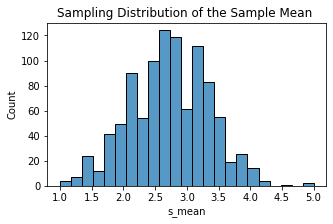

```python
fig = plt.figure(figsize=(5,3))
sns.histplot(sample_ready['s_mean'])
plt.title('Sampling Distribution of the Sample Mean ')
```

```python
#fig = plt.figure(figsize=(6,4))
#sns.displot(sample_ready['s_mean'],kind='kde')
#plt.title('Sampling Probability Distribution of the Sample Mean')
```

## #2 Discrete Exponential Distribution

Having performed the CLT on the previous sample I feel confident in my abilities and understanding to try again but this time on an exponential distribution. Immediately the difficulties that come to mind are how I will create my samples of the sample. I will not be able to apply the same technique as before, populating a list will all the results will be too large and inefficient as I would have to populate extreme numbers of x at the upper limit to population the list at the correct ration for x at the lower scale.

```python
def exponential_dist(x_lim, r=None, p0=None, decimal=None):
    if decimal ==None:
        decimal = 10
    if r == None:
        r=1
    if p0 == None:
        p0=1

    x_list = []
    f_list = []

    for i in range(0,(x_lim*decimal)):
        t = i/decimal
        x_list.append(t)
        f_list.append(p0*np.exp(r*t))



    return x_list,f_list
```

f(x) = 1*e^rt

This class's purpose is to populate a list with the distribution data, with variables to set the boundaries.

```python
#Call the exponential function to populate a list with the exponential data.
#x_lim: sets the x axis limit.
#r: is the exponetial rate
#decimal: affects how granular the data is decimal of 10 will take 10 values between x=1 and x=2

x,f  = exponential_dist(x_lim =10,r=2,decimal=100)

#Inserting the data into a DataFrame
d = {'x':x,'f(x)':f}
dist_data = pd.DataFrame(data=d)
#fig = plt.figure(figsize = (5,3))
#plt.plot(x,f)
```

The purpose of converting the data to a dataframe is to take advantage of vectorising when doing calculations.

```python
#Adding probability columns of each value
dist_data['p'] = dist_data['f(x)']/(dist_data['f(x)'].sum())
dist_data
```

|  | x | f(x) | p |
| --- | --- | --- | --- |
| 0 | 0.00 | 1.000000e+00 | 4.163807e-11 |
| 1 | 0.01 | 1.020201e+00 | 4.247921e-11 |
| 2 | 0.02 | 1.040811e+00 | 4.333735e-11 |
| 3 | 0.03 | 1.061837e+00 | 4.421282e-11 |
| 4 | 0.04 | 1.083287e+00 | 4.510598e-11 |
| ... | ... | ... | ... |
| 995 | 9.95 | 4.389956e+08 | 1.827893e-02 |
| 996 | 9.96 | 4.478639e+08 | 1.864819e-02 |
| 997 | 9.97 | 4.569114e+08 | 1.902491e-02 |
| 998 | 9.98 | 4.661416e+08 | 1.940923e-02 |
| 999 | 9.99 | 4.755583e+08 | 1.980133e-02 |

1000 rows × 3 columns

```python
dist_data['x*f(x)'] = dist_data['x']*dist_data['f(x)']
mean = (dist_data['x*f(x)'].sum())/(dist_data['f(x)'].sum())

dist_data['(x-u)^2'] = (dist_data['x']-mean)**2
dist_data['f(x)*((x-u)^2)'] =dist_data['f(x)']* dist_data['(x-u)^2']

variance = dist_data['f(x)*((x-u)^2)'].sum()/dist_data['f(x)'].sum()
std_deviation = math.sqrt(variance)

dist_data
```

|  | x | f(x) | p | x*f(x) | (x-u)^2 | f(x)*((x-u)^2) |
| --- | --- | --- | --- | --- | --- | --- |
| 0 | 0.00 | 1.000000e+00 | 4.163807e-11 | 0.000000e+00 | 90.154709 | 9.015471e+01 |
| 1 | 0.01 | 1.020201e+00 | 4.247921e-11 | 1.020201e-02 | 89.964909 | 9.178232e+01 |
| 2 | 0.02 | 1.040811e+00 | 4.333735e-11 | 2.081622e-02 | 89.775310 | 9.343911e+01 |
| 3 | 0.03 | 1.061837e+00 | 4.421282e-11 | 3.185510e-02 | 89.585910 | 9.512559e+01 |
| 4 | 0.04 | 1.083287e+00 | 4.510598e-11 | 4.333148e-02 | 89.396710 | 9.684230e+01 |
| ... | ... | ... | ... | ... | ... | ... |
| 995 | 9.95 | 4.389956e+08 | 1.827893e-02 | 4.368006e+09 | 0.207040 | 9.088972e+07 |
| 996 | 9.96 | 4.478639e+08 | 1.864819e-02 | 4.460725e+09 | 0.216240 | 9.684631e+07 |
| 997 | 9.97 | 4.569114e+08 | 1.902491e-02 | 4.555406e+09 | 0.225641 | 1.030979e+08 |
| 998 | 9.98 | 4.661416e+08 | 1.940923e-02 | 4.652093e+09 | 0.235241 | 1.096557e+08 |
| 999 | 9.99 | 4.755583e+08 | 1.980133e-02 | 4.750827e+09 | 0.245041 | 1.165315e+08 |

1000 rows × 6 columns

Inorder to get the $\mu$ and the $\sigma$ of the distribution, ive broken down the equation into seperate columns.

```
mean: 9.49
std deviation: 0.5
```

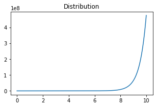

```python
print('mean:',round(mean,2))
print('std deviation:',round(std_deviation,2))

fig = plt.figure(figsize = (5,3))
plt.plot(x,f)
plt.title('Distribution')
plt.show()
```

```python
def Fetch_exp_samples(x,p,n=None,s_size=None,st = None,print_info=True):
    if n == None:
        n=5
    if s_size ==None:
        s_size = 10
    if st == None:
        show = True
    else:
        show = False

    start_range = x.iloc[0]
    step = round(x.iloc[len(x)-1] - x.iloc[len(x)-2],2)
    end_range = x.iloc[len(x)-1] + step

    samples=[]

    for i in range(0,s_size):
        s = []
        for i in range(0,n):
            s.append(np.random.choice(np.arange(start_range,end_range,step), p=p))

        samples.append(s)
    if print_info == True:
        print('x start',start_range)
        print('x stop',end_range)
        print('x step',step)
        print('\n')
        print(s_size,'Samples Fetched')
        print('n:',n)

    return samples
```

```python
def Fetch_dist_data(sample_list,show_table = None,plot=True,print_info=True):#from Fetch_exp_samples.
    if show_table == None:
        show = True
    else:
        show = False

    s = pd.DataFrame()
    s = pd.DataFrame(sample_list)
    s['sample_means'] = s.mean(axis=1)


    dist_data = s['sample_means'].value_counts().rename_axis('s_mean').reset_index(name='count')
    #losing rows?
    dist_data['val*f(x)'] = dist_data['s_mean']*dist_data['count']

    s_distribution_mean = dist_data['val*f(x)'].sum()/len(s)

    dist_data['(x-u)^2'] = (dist_data['s_mean'] - s_distribution_mean)**2
    dist_data['(x-u)^2 *f(x)'] =  dist_data['(x-u)^2'] *dist_data['count']
    variance = (dist_data['(x-u)^2 *f(x)'].sum())/len(s)
    std_d = math.sqrt(variance)

    if print_info == True:
        print('Mean of sample means:',round(s_distribution_mean,2))
        print('Standard error of the mean:',round(std_d,2))


    if plot == True:
        fig = plt.figure(figsize=(5,3))
        sns.histplot(s['sample_means'])
        plt.show()

    if show == True:
        return dist_data
    elif show ==False:
        return
```

```
x start 0.0
x stop 10.0
x step 0.01


10000 Samples Fetched
n: 50
Mean of sample means: 9.5
Standard error of the mean: 0.07
```

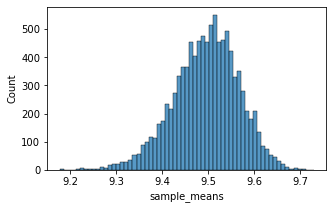

```python
#Fetch the samples by creating a random number set with the probabilities of the x values between the x range.
#x: is the column of x values. this is to set the range and step.
#p: is the probability for each x value based on frequency of the data.
#n: is the size of each sample.
#s_size: is the total number of samples fetched.

s = Fetch_exp_samples(x =dist_data['x'],p = dist_data['p'],n=50,s_size=10000)

#After the samples are created, this function will takes those samples and calculate the mean and std deviation.
#then plot the distribution.
Fetch_dist_data(s,show_table=False)
```

$n=50$

$\mu_\bar{X} = 9.5 $

$\sigma_\bar{X}$ = 0.07

### Confirming standard error of the mean

\begin{equation*} \underset{\bar{X}}{\sigma^2} = \frac{\sigma^2_\mu}{n} \space\space\space\space or \space\space\space\space \sigma_\bar{X} = \frac{\sigma_\mu}{\sqrt{n}} \end{equation*}

```python
print('original std deviation = 0.5')
print('N = 50')


print('Sample deviation = ', 0.5/math.sqrt(50))
```

```
original std deviation = 0.5
N = 50
Sample deviation =  0.07071067811865475
```

It's interesting to see how the change in r affects the std deviation, although this may be obvious after running a few different criteria I feel I have a much better understanding of how and why.

Here we can get a visual sense of the central limit theorem of as n approaches infinity we get a normal distribution. In practice at around n = 50, I was able to produce a fair representation of a normal distribution. To full visualise the impact of n I ran some simulations with n in the lower ranges to see what kind of distribution is produced.

```
x start 0.0
x stop 10.0
x step 0.01


10000 Samples Fetched
n: 10
Mean of sample means: 9.49
Standard error of the mean: 0.16
```

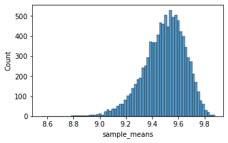

```python
s1 = Fetch_exp_samples(x =dist_data['x'],p = dist_data['p'],n=10,s_size=10000,print_info =True)
Fetch_dist_data(s1,False,print_info = True)
```

By lowering the sample n the graph is more of a left skew distribution, rather than a normal distribution. This makes sense as a small sample size usually requires different methods such as a T distribution

## SE of the mean as n increases.

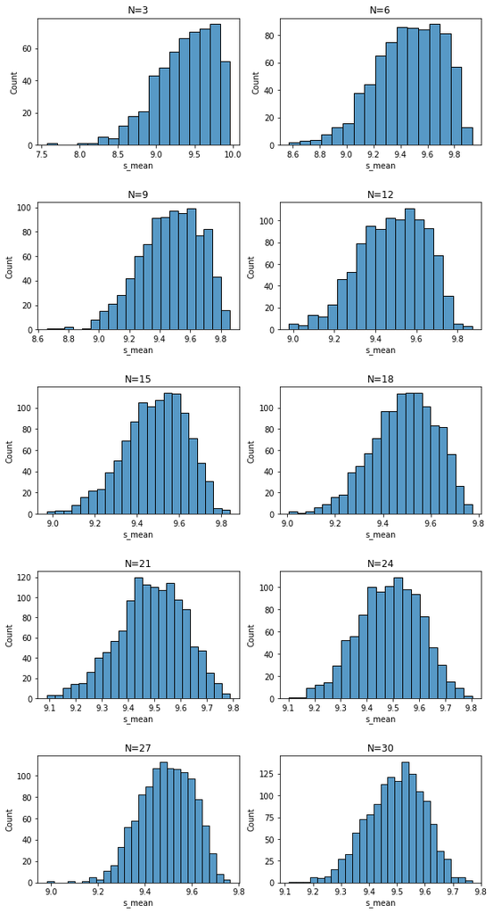

```python
fig = plt.figure(figsize=(10,20))
fig.subplots_adjust(left=None, bottom=None, right=None, top=None, wspace=None, hspace=0.45)
for i in range(1,11):
    n = i*3

    s = Fetch_exp_samples(x =dist_data['x'],p = dist_data['p'],n=n,s_size=2000,print_info=False)
    results = Fetch_dist_data(s,plot = False,print_info =False)

    n= str(n)
    ax = fig.add_subplot(5,2,i)
    sns.histplot(results['s_mean'])
    ax.set_title('N='+n)
```

Standard error as n increases

```python
print('n=3' ,'standard error =', round(0.5/math.sqrt(3),3))
print('n=6' ,'standard error =', round(0.5/math.sqrt(6),3))
print('n=9' ,'standard error =', round(0.5/math.sqrt(9),3))
print('n=12','standard error =', round(0.5/math.sqrt(12),3))
print('n=15','standard error =', round(0.5/math.sqrt(15),3))
print('n=18','standard error =', round(0.5/math.sqrt(18),3))
print('n=21','standard error =', round(0.5/math.sqrt(21),3))
print('n=24','standard error =', round(0.5/math.sqrt(24),3))
print('n=27','standard error =', round(0.5/math.sqrt(27),3))
print('n=30','standard error =', round(0.5/math.sqrt(30),3))
```

```
n=3 standard error = 0.289
n=6 standard error = 0.204
n=9 standard error = 0.167
n=12 standard error = 0.144
n=15 standard error = 0.129
n=18 standard error = 0.118
n=21 standard error = 0.109
n=24 standard error = 0.102
n=27 standard error = 0.096
n=30 standard error = 0.091
```